# Spotify Analysis

Aliya Alimujiang, Rui Huang, Sujata Biradar

2020-12-04

# Abstract

In this analysis, we explore the tracks and artists data, which are both stored in the “output” folder.

# Analysis

For this analysis, we will use the tidyverse to explore the tracks dataset stored in the “output” folder. The data was retrieved through Spotify API request.

```r
library(tidyverse)
library(corrplot)
library(gridExtra)
library(grid)
library(lubridate)
library(factoextra)
```

```r
tracks <- read_csv("../output/tracks.csv")
artists <- read_csv("../output/artists.csv")

glimpse(tracks)
```

```
## Rows: 37,311
## Columns: 18
## $ track_id         <chr> "1EzrEOXmMH3G43AXT1y7pA", "0IktbUcnAGrvD03AWnz3Q8", …
## $ track_name       <chr> "I'm Yours", "Lucky", "I Won't Give Up", "93 Million…
## $ track_popularity <dbl> 83, 76, 73, 53, 66, 65, 48, 61, 60, 60, 75, 73, 72, …
## $ release_year     <dbl> 2008, 2008, 2012, 2012, 2018, 2020, 2014, 2002, 2020…
## $ danceability     <dbl> 0.686, 0.623, 0.585, 0.573, 0.643, 0.710, 0.579, 0.5…
## $ energy           <dbl> 0.457, 0.417, 0.303, 0.454, 0.638, 0.615, 0.363, 0.8…
## $ key              <dbl> 11, 0, 4, 3, 1, 0, 7, 10, 6, 7, 2, 10, 0, 5, 6, 1, 1…
## $ loudness         <dbl> -8.322, -8.699, -10.058, -10.286, -4.947, -8.230, -1…
## $ mode             <dbl> 1, 1, 1, 1, 0, 1, 1, 1, 1, 1, 0, 0, 1, 1, 0, 1, 1, 1…
## $ speechiness      <dbl> 0.0468, 0.0354, 0.0398, 0.0258, 0.0407, 0.1330, 0.03…
## $ acousticness     <dbl> 0.59500, 0.29600, 0.69400, 0.47900, 0.20400, 0.03840…
## $ instrumentalness <dbl> 0.00e+00, 0.00e+00, 0.00e+00, 1.36e-05, 0.00e+00, 0.…
## $ liveness         <dbl> 0.1050, 0.1350, 0.1150, 0.0974, 0.0707, 0.2830, 0.11…
## $ valence          <dbl> 0.7180, 0.7210, 0.1420, 0.5150, 0.6000, 0.7460, 0.07…
## $ tempo            <dbl> 150.953, 130.032, 136.703, 140.187, 82.001, 90.263, …
## $ duration_ms      <dbl> 242187, 191360, 240166, 216387, 226107, 239698, 2569…
## $ time_signature   <dbl> 4, 4, 3, 4, 4, 4, 4, 4, 4, 4, 4, 4, 4, 4, 4, 4, 3, 4…
## $ artist_id        <chr> "4phGZZrJZRo4ElhRtViYdl", "4phGZZrJZRo4ElhRtViYdl", …
```

```r
glimpse(artists)
```

```
## Rows: 4,184
## Columns: 5
## $ artist_id         <chr> "4phGZZrJZRo4ElhRtViYdl", "2Sqr0DXoaYABbjBo9HaMkM",…
## $ artist_name       <chr> "Jason Mraz", "Sara Bareilles", "NEEDTOBREATHE", "B…
## $ artist_popularity <dbl> 80, 75, 72, 70, 75, 71, 70, 71, 69, 84, 72, 67, 67,…
## $ total_followers   <dbl> 5655509, 1521757, 611481, 256138, 1974147, 804480, …
## $ artist_genre      <chr> "acoustic", "acoustic", "acoustic", "acoustic", "ac…
```

There are 37311 track records:

- `track_id`: An unique identifier for each track.
- `track_name`: Name of each track.
- `track_popularity`: The popularity of the track. The value ranges from 0 to 100, with 100 being the most popular.
- `release_year`: The year the track got released.
- `danceability` to `time_signature`: These are 13 audio features defined by Spotify. Please view “audio_features_dictionary” in the “output” folder.
- `artist_id`: An unique identifier for each artist of the corresponding track. Tracks can be joined with the artists data using this key.

There are 4184 artists in the artists dataset:

- `artist_id`: An unique identifier for each artist.
- `artist_name`: Name of each artist.
- `artist_popularity`: The popularity of each artist. The value ranges from 0 to 100, with 100 being the most popular.
- `total_followers`: Total followers on Spotify of each artist.
- `artist_genre`: The genre of each artist.

Since `duration_s` is represented in millisecond. We want to convert it to second.

```r
tracks <- tracks %>%
  mutate(duration_s = dmilliseconds(duration_ms)) %>%
  select(track_id:time_signature, duration_s, artist_id, -duration_ms)
```

First, let’s take a look at the descriptive summary for our data:

```r
tracks %>%
  select(-track_id, -track_name, -release_year, -artist_id) %>%
  summary()
```

```
##  track_popularity  danceability        energy            key
##  Min.   : 0.00    Min.   :0.0000   Min.   :0.0000   Min.   : 0.000
##  1st Qu.:37.00    1st Qu.:0.4450   1st Qu.:0.4570   1st Qu.: 2.000
##  Median :48.00    Median :0.5710   Median :0.6740   Median : 5.000
##  Mean   :46.91    Mean   :0.5593   Mean   :0.6334   Mean   : 5.218
##  3rd Qu.:59.00    3rd Qu.:0.6920   3rd Qu.:0.8530   3rd Qu.: 8.000
##  Max.   :99.00    Max.   :0.9930   Max.   :1.0000   Max.   :11.000
##     loudness            mode        speechiness       acousticness
##  Min.   :-49.531   Min.   :0.000   Min.   :0.00000   Min.   :0.00000
##  1st Qu.:-10.459   1st Qu.:0.000   1st Qu.:0.03590   1st Qu.:0.01405
##  Median : -7.185   Median :1.000   Median :0.04880   Median :0.16100
##  Mean   : -8.526   Mean   :0.635   Mean   :0.08784   Mean   :0.31405
##  3rd Qu.: -5.041   3rd Qu.:1.000   3rd Qu.:0.08630   3rd Qu.:0.59800
##  Max.   :  1.893   Max.   :1.000   Max.   :0.96300   Max.   :0.99600
##  instrumentalness      liveness         valence           tempo
##  Min.   :0.000000   Min.   :0.0000   Min.   :0.0000   Min.   :  0.00
##  1st Qu.:0.000000   1st Qu.:0.0959   1st Qu.:0.2440   1st Qu.: 98.74
##  Median :0.000133   Median :0.1270   Median :0.4490   Median :121.83
##  Mean   :0.173020   Mean   :0.2038   Mean   :0.4656   Mean   :121.72
##  3rd Qu.:0.115000   3rd Qu.:0.2580   3rd Qu.:0.6790   3rd Qu.:140.05
##  Max.   :1.000000   Max.   :0.9950   Max.   :1.0000   Max.   :219.45
##  time_signature    duration_s
##  Min.   :0.000   Min.   :8.213s
##  1st Qu.:4.000   1st Qu.:184.379s (~3.07 minutes)
##  Median :4.000   Median :223.039s (~3.72 minutes)
##  Mean   :3.902   Mean   :237.857286939508s (~3.96 minutes)
##  3rd Qu.:4.000   3rd Qu.:271.6735s (~4.53 minutes)
##  Max.   :5.000   Max.   :4719.013s (~1.31 hours)
```

```r
artists %>%
  select(-artist_id, -artist_name, -artist_genre) %>%
  summary()
```

```
##  artist_popularity total_followers
##  Min.   :  0.0     Min.   :       2
##  1st Qu.: 52.0     1st Qu.:   39185
##  Median : 62.0     Median :  185622
##  Mean   : 59.7     Mean   : 1080051
##  3rd Qu.: 70.0     3rd Qu.:  726605
##  Max.   :100.0     Max.   :71826891
```

Based on the summary statistics above, on average, each song lasts for approximately 4 minutes. On average, an artist has approximately 1.08m followers in this dataset. Track popularity has an average at 47 and artist popularity has an average around around 60. Based on their medians and means, both types of popularity distributions are somewhat normal.

Let’s take a look at the distributions of the track popularity and the artist popularity:

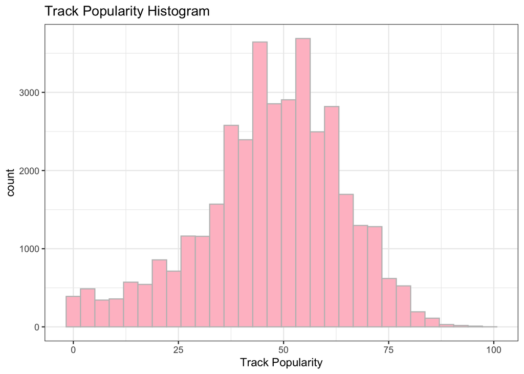

```r
tracks %>%
  ggplot() +
  geom_histogram(aes(x = track_popularity), fill = 'pink', color = 'grey') +
  labs(title = 'Track Popularity Histogram', x = 'Track Popularity')
```

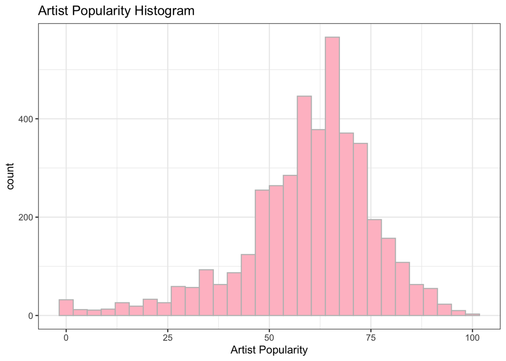

```r
artists %>%
  ggplot() +
  geom_histogram(aes(x = artist_popularity), fill = 'pink', color = 'grey') +
  labs(title = 'Artist Popularity Histogram', x = 'Artist Popularity')
```

Based on the histograms above, both artist and track popularities have somewhat normal distribution.

Let’s run a correlation plot:

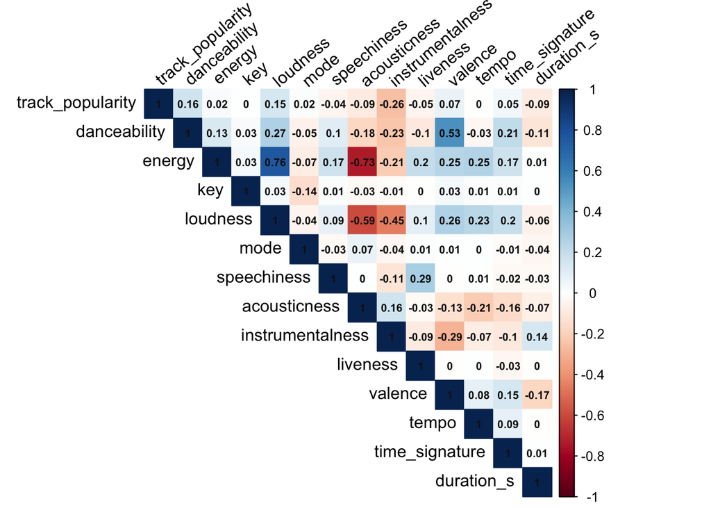

```r
track_corr <- tracks %>%
  select(track_popularity,
         danceability:duration_s) %>%
  cor()

corrplot(track_corr, method="color", type = "upper", tl.col="black",tl.srt=40, addCoef.col = "gray8", diag = T, number.cex = 0.65)
```

While most correlations are low, there are some interesting points:

- There is a high positive correlation between `energy` and `loudness` of a track.
- There is a strong negative correlation between `energy` and `acousticness` in a track.
- There is a positive correlation between `danceability` and `valence.`
- There is no strong correlation between any of the track audio features and the track popularity, which is good.

Based on the correlation plot above, we want to take a look at the relationships between variables that are highly correlated:

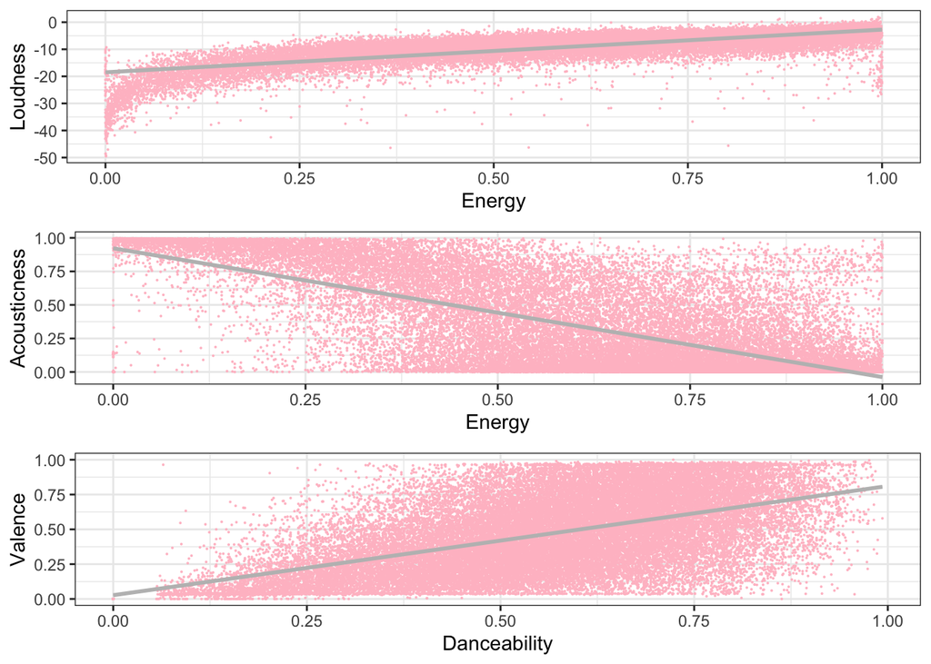

```r
# Create a function for relationship
jitter <- function(x, y, data) {
  ggplot(data, aes(x, y)) +
  geom_jitter(size = 0.01, color = 'pink') +
  geom_smooth(method = 'lm', color = 'grey', size= 1, alpha = 0.5)
}

# energy vs loudness
energy_loudness <- jitter(x = tracks$energy, y = tracks$loudness, data = tracks) + labs(x = 'Energy', y = 'Loudness')

# energy vs acousticness
acousticness_energy <- jitter(x = tracks$energy, y = tracks$acousticness, data = tracks) + labs(x = 'Energy', y = 'Acousticness')

# danceability vs valence
danceability_valence <- jitter(x = tracks$danceability, y = tracks$valence, data = tracks) + labs(x = 'Danceability', y = 'Valence')

grid.arrange(energy_loudness, acousticness_energy, danceability_valence, nrow = 3)
```

```r
tracks_artists <- tracks %>%
  inner_join(artists, by = 'artist_id')

# Removing duplicates if any
tracks_artists <- tracks_artists[!duplicated(tracks_artists$track_id),]
```

[figure not shown]

```r
tracks_artists %>%
  select(track_name, artist_name, artist_genre, track_popularity)%>%
  group_by(artist_name)%>%
  filter(!is.na(track_name))%>%
  filter(!is.na(artist_name))%>%
  arrange(desc(track_popularity))%>%
  head(n = 10)%>%
  ggplot(mapping = aes(x = artist_name, y = track_name, color = artist_name, fill = artist_genre, size = track_popularity ))+
  geom_point()+
  theme_minimal()+
  labs(x = 'track_name', y = 'artist_name', title = 'Top ten most popular tracks')+
  theme(plot.title = element_text(hjust=0.5),legend.position ='bottom')
```

Let’s take a look at the key:

[figure not shown]

```r
tracks$key <- as.character(tracks$key)
library(plyr)
tracks$key <- revalue(tracks$key, c("0" = "C", "1" = "C♯,D♭", "2" = "D", "3" = "D♯,E♭", "4" = "E", "5" =  "F", "6" = "F♯,G♭","7" = "G","8" = "G♯,A♭","9" = "A","10" = "A♯,B♭","11" = "B"))

detach("package:plyr", unload=TRUE)
song_keys <- tracks %>%
  group_by(key) %>%
  summarise(n_key = n()) %>%
  arrange(desc(n_key))

library(plyr)
song_keys$key <- factor(song_keys$key, levels = song_keys$key[order(song_keys$n_key)]) # in order to visualise the keys in descending order

ggplot(song_keys, aes(x = reorder(key,-n_key), y = n_key, fill = reorder(key,-n_key))) +
  geom_bar(stat = "identity") +
  labs(title = "Distribution of the Keys of Top Songs", x = "Keys", y = "Count of Keys on the Top 100") +
  geom_text(aes(label=n_key), position = position_stack(vjust = 0.8)) +
  theme_bw() +
  theme(plot.title = element_text(size=15,face = "bold"), axis.title = element_text(size=12)) +
  theme(legend.position="none")
```

Based on the plot above, C key is the most common key.

Let’s take a look at density plots on some audio features:

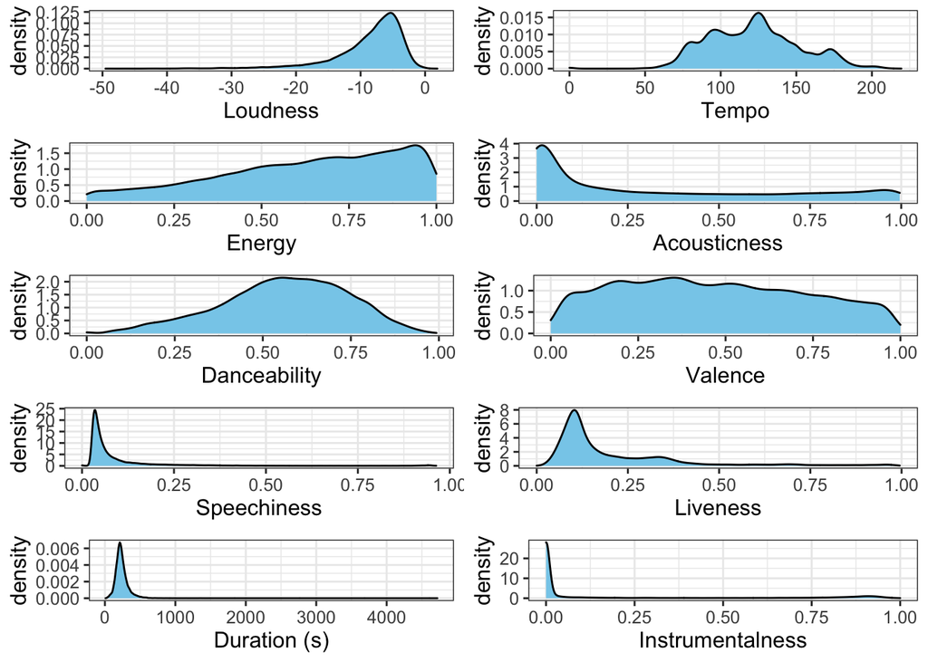

```r
# Create a density plot function
density_plot <- function(x) {
  ggplot(tracks) +
    geom_density(aes(x), fill = 'skyblue') +
    theme_bw() +
    theme(plot.title = element_text(size = 14, face = "bold"),
            text = element_text(size = 12)) +
    theme(legend.title=element_blank())
}

# Prepare density plots
loudness_density <- density_plot(tracks$loudness) + labs(x = 'Loudness')
tempo_density <- density_plot(tracks$tempo) + labs(x = 'Tempo')
energy_density <- density_plot(tracks$energy) + labs(x = 'Energy')
acousticness_density <- density_plot(tracks$acousticness) + labs(x = 'Acousticness')
danceability_density <- density_plot(tracks$danceability) + labs(x = 'Danceability')
valence_density <- density_plot(tracks$valence) + labs(x = 'Valence')
speechiness_density <- density_plot(tracks$speechiness) + labs(x = 'Speechiness')
liveness_density <- density_plot(tracks$liveness) + labs(x = 'Liveness')
instrumentalness_density <- density_plot(tracks$instrumentalness) + labs(x = 'Instrumentalness')
duration_s_density <- density_plot(tracks$duration_s) + labs(x = 'Duration (s)')

# Grid plots
grid.arrange(loudness_density, tempo_density, energy_density, acousticness_density, danceability_density, valence_density, speechiness_density, liveness_density, duration_s_density, instrumentalness_density, nrow = 5)
```

# Conclusion (Needs to be edited)

After running initial analysis, we found that there are some correlation issues residing in audio features, which means a variable selection method could be used in our prediction analysis later. Both distributions for track popularity and artist popularity are somewhat normal, which is a good thing.

# References

We used the following resources:

- https://developer.spotify.com/documentation/web-api/reference/tracks/get-track/
- https://developer.spotify.com/documentation/web-api/reference/tracks/get-audio-features/
- https://developer.spotify.com/documentation/web-api/reference/artists/get-artist/